# Caravan Insurance Challenge

Yash

June 24, 2018

# Predicting Caravan Insurance Purchases

## The data is provided by the Caravan Insurance company of its customer base. Some of the customers have already bought policies for fire risk , auto , boat etc from Caravan. Using this information we need predict whether they will purchase Caravan Home Insurance

### Load the training data and inspect the data

```r
Cins <-  read.csv.sql("C1.csv","select * from file where ORIGIN = 'train' ", header=TRUE, sep=",")

### Exclude the  first column
Caravan_train <- Cins[-1]


### Check the dimensions
dim(Caravan_train )
```

```
## [1] 5822   86
```

```r
#names(Caravan_train )


# Inspect the data
str(Caravan_train )
```

```
## 'data.frame':    5822 obs. of  86 variables:
##  $ Customer_Subtype                             : int  33 37 37 9 40 23 39 33 33 11 ...
##  $ Number_of_houses                             : int  1 1 1 1 1 1 2 1 1 2 ...
##  $ Avg_size_household                           : int  3 2 2 3 4 2 3 2 2 3 ...
##  $ Avg_age                                      : int  2 2 2 3 2 1 2 3 4 3 ...
##  $ Customer_main_type                           : int  8 8 8 3 10 5 9 8 8 3 ...
##  $ Roman_catholic                               : int  0 1 0 2 1 0 2 0 0 3 ...
##  $ Protestant                                   : int  5 4 4 3 4 5 2 7 1 5 ...
##  $ Other_religion                               : int  1 1 2 2 1 0 0 0 3 0 ...
##  $ No_religion                                  : int  3 4 4 4 4 5 5 2 6 2 ...
##  $ Married                                      : int  7 6 3 5 7 0 7 7 6 7 ...
##  $ Living_together                              : int  0 2 2 2 1 6 2 2 0 0 ...
##  $ Other_relation                               : int  2 2 4 2 2 3 0 0 3 2 ...
##  $ Singles                                      : int  1 0 4 2 2 3 0 0 3 2 ...
##  $ Household_without_children                   : int  2 4 4 3 4 5 3 5 3 2 ...
```

[output cut: 72 more lines]

```r
#head(Caravan_train )
```

### check for missing values

```r
Missing_Count <-  sum(is.na.data.frame(Caravan_train))
print(paste ("Missing count -> " , Missing_Count))
```

```
## [1] "Missing count ->  0"
```

### Its an highly unbalanced dataset. This is evident from the below bar chart

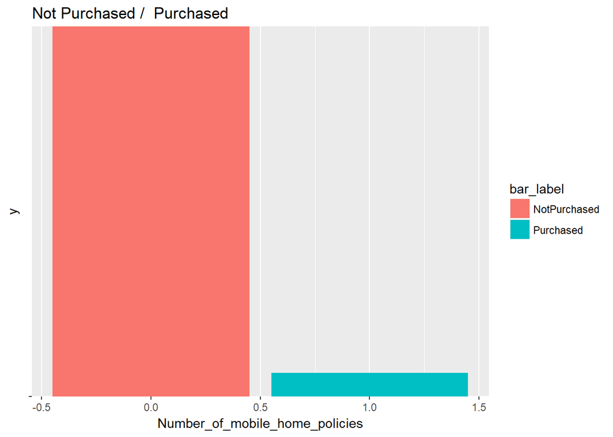

```r
bar_label <- factor(Caravan_train$Number_of_mobile_home_policies  , labels=c("NotPurchased","Purchased"))
#bar_label
ggplot(data =  Caravan_train, aes(y = "", x =Number_of_mobile_home_policies , fill = bar_label ) )+
  geom_bar(stat = "identity" ) +
  ggtitle("Not Purchased /  Purchased")
```

```r
print(paste("Insurance count : 0 -> not having insurance , 1 - Having Insurance"))
```

```
## [1] "Insurance count : 0 -> not having insurance , 1 - Having Insurance"
```

```r
table(Caravan_train$Number_of_mobile_home_policies)
```

```
##
##    0    1
## 5474  348
```

## Data Exploratory

### Education levels of population who have bought insurance. People with low education level are more likey to buy

```r
temp1 <-  ""
templ1 <-  ""
temp2 <- ""
grp_data <-  ""
grp_data <- sqldf(" select High_level_education  , Medium_level_education , Lower_level_education   from Caravan_train where Number_of_mobile_home_policies  = 1  ")
class(grp_data)
```

```
## [1] "data.frame"
```

```r
dim(grp_data)
```

```
## [1] 348   3
```

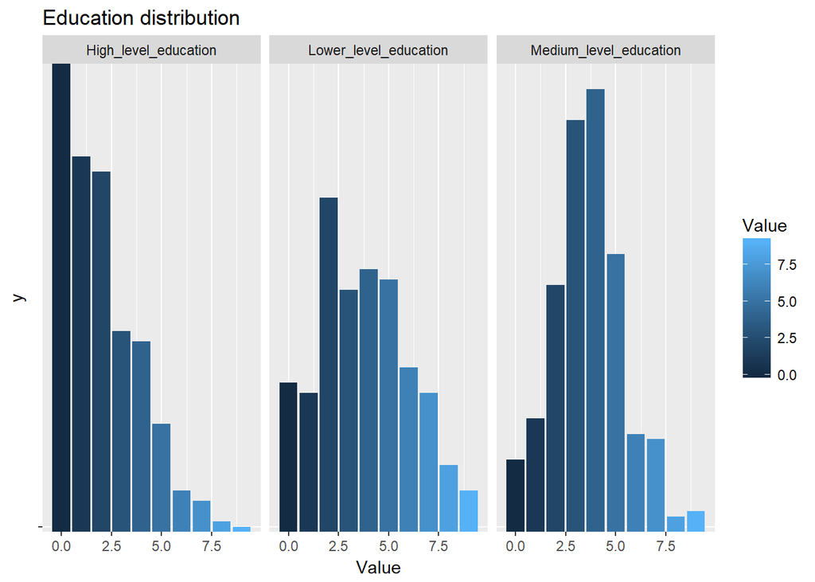

```r
temp2 <- gather(grp_data,Education,Value,1:3)

ggplot(data= temp2, aes (x = Value,y = "",fill = Value)) +
  geom_bar(stat = 'identity') +
  facet_grid(. ~ Education ) +
  ggtitle("Education distribution")
```

### Distribution of insurance buyers by Car ownership. People with 1 car are more likely to buy

```r
temp1 <-  ""
templ1 <-  ""
temp2 <- ""
grp_data <-  ""
grp_data <- sqldf(" select X1_car , X2_cars , No_car from Caravan_train where Number_of_mobile_home_policies  = 1  ")
class(grp_data)
```

```
## [1] "data.frame"
```

```r
dim(grp_data)
```

```
## [1] 348   3
```

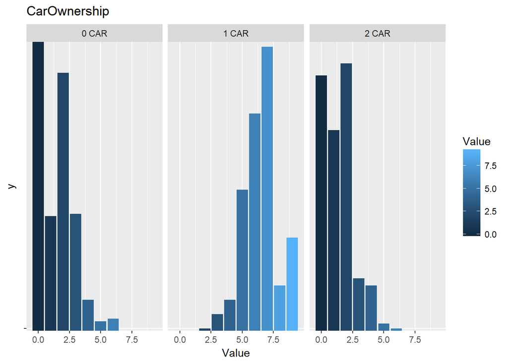

```r
names(grp_data) <- c("1 CAR","2 CAR","0 CAR")


temp2 <- gather(grp_data,CarOwnership,Value,1:3)

ggplot(data= temp2, aes (x = Value,y = "",fill = Value)) +
  geom_bar(stat = 'identity') +
  facet_grid(. ~ CarOwnership  ) +
  ggtitle("CarOwnership")
```

### Insurance policy count. We can see corelation between people having car policies3 party policy and fire risk policies.

```r
  temp1 <-  ""
templ1 <-  ""
temp2 <- ""
grp_data <-  ""
grp_data <- sqldf(" select
                   private_third_party_insurance
, third_party_insurance_firms
, third_party_insurane_agriculture
, car_policies
, delivery_van_policies
, Contribution_motorcycle_scooter
, lorry_policies
, trailer_policies
, tractor_policies
, agricultural_machines_policies
, moped_policies
, life_insurances
, private_accident_insurance_policies
, family_accidents_insurance_policies
, disability_insurance_policies
, fire_policies
, surfboard_policies
, boat_policies
, bicycle_policies
, property_insurance_policies
, social_security_insurance_policies

 from Caravan_train where Number_of_mobile_home_policies  = 1  ")
class(grp_data)
```

```
## [1] "data.frame"
```

```r
dim(grp_data)
```

```
## [1] 348  21
```

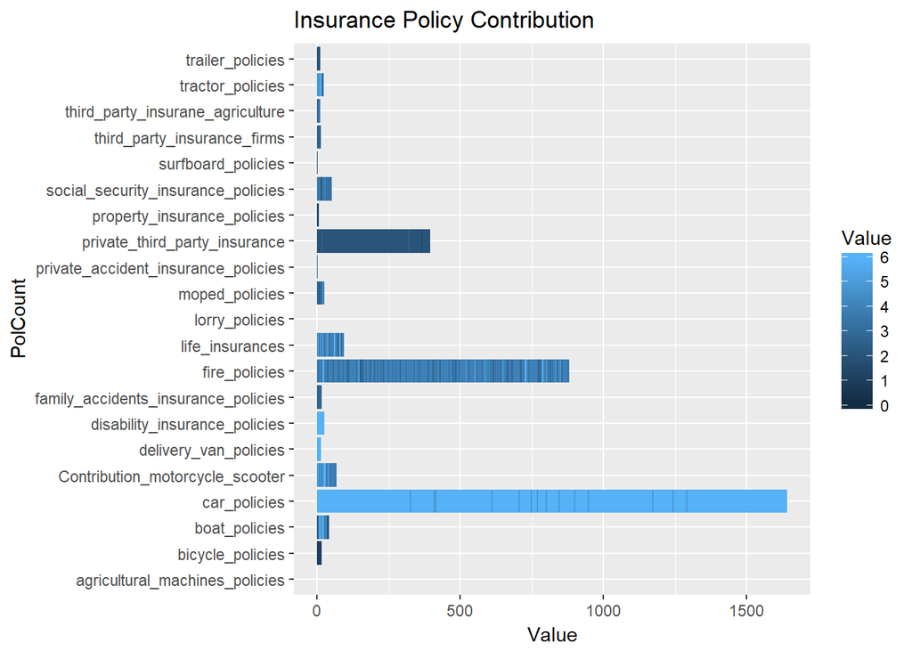

```r
temp2 <- gather(grp_data,PolCount,Value,1:21)

ggplot(data= temp2, aes (x = PolCount,y = Value,fill = Value)) +
  geom_bar(stat = 'identity' )  +
  ggtitle("Insurance Policy Contribution") +
  coord_flip()
```

```r
Caravan_train_SUB56  <-  subset(Caravan_train, select = c(   car_policies
                                                      ,Lower_level_education
                                                      ,fire_policies
  ,Average_income
  ,private_third_party_insurance
  ,X1_car
  ,Social_class_C
  ,Other_religion
  ,boat_policies
  ,No_car
  ,Customer_Subtype
  ,Middle_management
  ,Income_75.122.000
  ,tractor_policies
  ,Social_class_B1
  ,Social_class_D
  ,High_level_education
  ,Protestant
  ,Medium_level_education
  ,bicycle_policies
  ,Income_45.75.000
  ,Unskilled_labourers
  ,Farmer
  ,Purchasing_power
  ,Number_of_car_policies
  ,Income_._30
  ,Customer_main_type
  ,Household_with_children
  ,Income_30.45.000
  ,Rented_house
  ,moped_policies
  ,Married
  ,Social_class_B2
  ,X2_cars
  ,Skilled_labourers
  ,Social_class_A
  ,Household_without_children
  ,High_status
  ,No_religion
  ,Entrepreneur
  ,social_security_insurance_policies
  ,Home_owners
  ,third_party_insurane_agriculture
  ,Living_together
  ,Avg_size_household
  ,Avg_age
  ,Number_of_houses
  ,Singles
  ,Roman_catholic
  ,Other_relation
  ,Income_.123.000
  ,life_insurances
  ,National_Health_Service
  ,Contribution_motorcycle_scooter
  ,Private_health_insurance
  ,Number_of_life_insurances  , Number_of_mobile_home_policies   )  )

dim(Caravan_train_SUB56)
```

```
## [1] 5822   57
```

```r
head(Caravan_train_SUB56)
```

```
##   car_policies Lower_level_education fire_policies Average_income
## 1            6                     7             5              4
## 2            0                     4             2              5
## 3            6                     4             2              3
## 4            6                     2             2              4
## 5            0                     0             6              6
## 6            6                     4             0              3
##   private_third_party_insurance X1_car Social_class_C Other_religion
## 1                             0      8              6              1
## 2                             2      7              5              1
## 3                             2      7              4              2
## 4                             0      9              4              2
## 5                             0      6              0              1
## 6                             0      5              4              0
##   boat_policies No_car Customer_Subtype Middle_management
```

[output cut: 97 more lines]

## CLASSIFICATION USING RANDOM FOREST

### STEP 1 - USE UNBALANCED DATA

### STEP 2 - USE UNDER SAMPLED DATA

### STEP 3 - PERFORMANCE TUNING

### RF USING UNBALANCED DATA

```r
# use unbalanced data

set.seed(123457)

attach(Caravan_train_SUB56)
rf.Unb.Train <-  randomForest( as.factor(Number_of_mobile_home_policies)  ~ . , data = Caravan_train_SUB56,importance = TRUE )
print(rf.Unb.Train)
```

```
##
## Call:
##  randomForest(formula = as.factor(Number_of_mobile_home_policies) ~      ., data = Caravan_train_SUB56, importance = TRUE)
##                Type of random forest: classification
##                      Number of trees: 500
## No. of variables tried at each split: 7
##
##         OOB estimate of  error rate: 6.75%
## Confusion matrix:
##      0  1 class.error
## 0 5415 59  0.01077822
## 1  334 14  0.95977011
```

```r
# grab the error matrix

err <- rf.Unb.Train$err.rate
head(err)
```

```
##             OOB          0         1
## [1,] 0.11230697 0.06361829 0.8960000
## [2,] 0.10155799 0.05238971 0.8960396
## [3,] 0.09963269 0.04980469 0.8846154
## [4,] 0.09752100 0.04576160 0.9109589
## [5,] 0.09398281 0.04148871 0.9056604
## [6,] 0.09159049 0.03929961 0.9060606
```

```r
dim(rf.Unb.Train$err.rate)
```

```
## [1] 500   3
```

```r
# Look at final OOB error rate (last row in err matrix)
oob_err <- err[nrow(err),"OOB"]
print(oob_err)
```

```
##        OOB
## 0.06750258
```

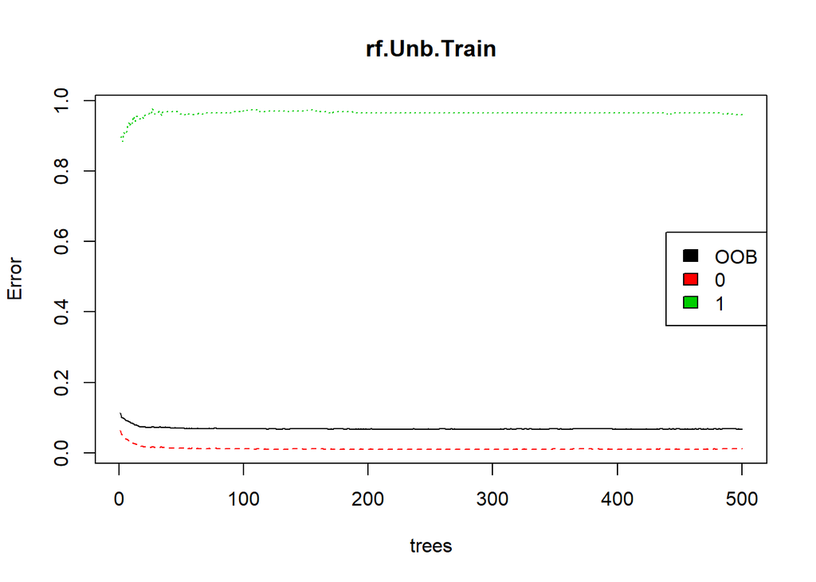

```r
# Plot the model trained in the previous exercise
plot(rf.Unb.Train)

# Add a legend since it doesn't have one by default
legend(x = "right",
       legend = colnames(err),
       fill = 1:ncol(err))
```

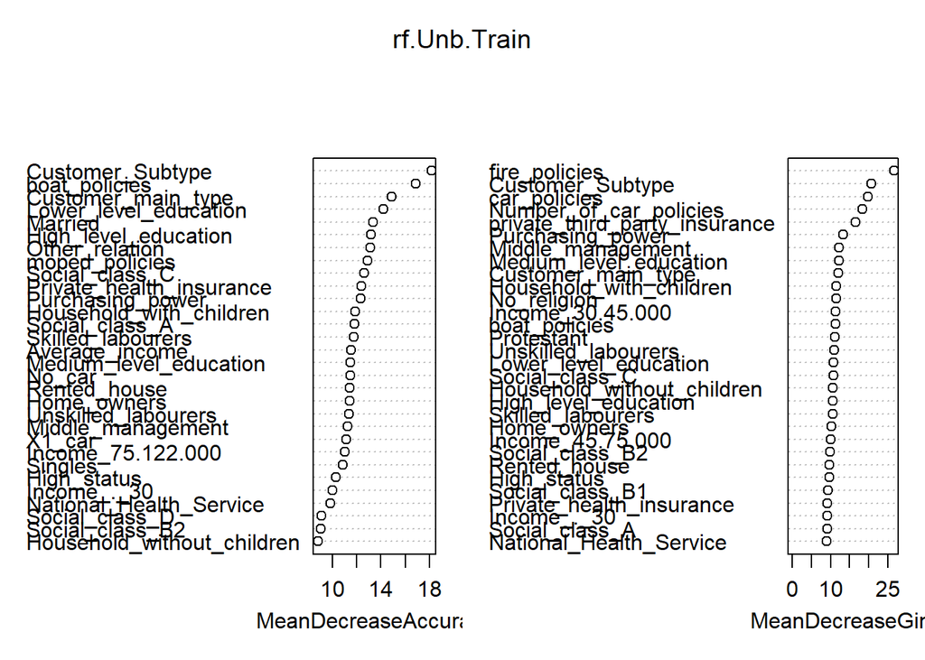

```r
#important(rf.Unb.Train)
varImpPlot(rf.Unb.Train)
```

```r
CinsTest <-  read.csv.sql("C2.csv","select * from file where ORIGIN = 'test' ", header=TRUE, sep=",")


# Exclude the  first column
# Caravan_test <- CinsTest[-1]

Caravan_test <-  subset(CinsTest, select = c(   car_policies
                                                      ,Lower_level_education
                                                      ,fire_policies
  ,Average_income
  ,private_third_party_insurance
  ,X1_car
  ,Social_class_C
  ,Other_religion
  ,boat_policies
  ,No_car
  ,Customer_Subtype
  ,Middle_management
  ,Income_75.122.000
  ,tractor_policies
  ,Social_class_B1
  ,Social_class_D
  ,High_level_education
  ,Protestant
  ,Medium_level_education
  ,bicycle_policies
  ,Income_45.75.000
  ,Unskilled_labourers
  ,Farmer
  ,Purchasing_power
  ,Number_of_car_policies
  ,Income_._30
  ,Customer_main_type
  ,Household_with_children
  ,Income_30.45.000
  ,Rented_house
  ,moped_policies
  ,Married
  ,Social_class_B2
  ,X2_cars
  ,Skilled_labourers
  ,Social_class_A
  ,Household_without_children
  ,High_status
  ,No_religion
  ,Entrepreneur
  ,social_security_insurance_policies
  ,Home_owners
  ,third_party_insurane_agriculture
  ,Living_together
  ,Avg_size_household
  ,Avg_age
  ,Number_of_houses
  ,Singles
  ,Roman_catholic
  ,Other_relation
  ,Income_.123.000
  ,life_insurances
  ,National_Health_Service
  ,Contribution_motorcycle_scooter
  ,Private_health_insurance
  ,Number_of_life_insurances  , Number_of_mobile_home_policies   )  )



dim(Caravan_test)
```

```
## [1] 4000   57
```

```r
names(Caravan_test)
```

```
##  [1] "car_policies"
##  [2] "Lower_level_education"
##  [3] "fire_policies"
##  [4] "Average_income"
##  [5] "private_third_party_insurance"
##  [6] "X1_car"
##  [7] "Social_class_C"
##  [8] "Other_religion"
##  [9] "boat_policies"
## [10] "No_car"
## [11] "Customer_Subtype"
## [12] "Middle_management"
## [13] "Income_75.122.000"
## [14] "tractor_policies"
## [15] "Social_class_B1"
```

[output cut: 42 more lines]

```r
# Generate predicted classes using the model object
rf.Unb.Prediction <-  predict(rf.Unb.Train,newdata = Caravan_test,type = "class")

# Calculate the confusion matrix for the test set

cm <- confusionMatrix(as.factor(rf.Unb.Prediction),
                      reference = as.factor(Caravan_test$Number_of_mobile_home_policies) )
print(cm)
```

```
## Confusion Matrix and Statistics
##
##           Reference
## Prediction    0    1
##          0 3733  225
##          1   29   13
##
##                Accuracy : 0.9365
##                  95% CI : (0.9285, 0.9439)
##     No Information Rate : 0.9405
##     P-Value [Acc > NIR] : 0.8645
##
##                   Kappa : 0.0764
##  Mcnemar's Test P-Value : <2e-16
##
##             Sensitivity : 0.99229
##             Specificity : 0.05462
##          Pos Pred Value : 0.94315
##          Neg Pred Value : 0.30952
##              Prevalence : 0.94050
##          Detection Rate : 0.93325
##    Detection Prevalence : 0.98950
##       Balanced Accuracy : 0.52346
##
##        'Positive' Class : 0
##
```

```r
# Compare test set accuracy to OOB accuracy
paste0("Test Accuracy: ", cm$overall[1])
```

```
## [1] "Test Accuracy: 0.9365"
```

```r
paste0("OOB Accuracy: ", 1 - oob_err)
```

```
## [1] "OOB Accuracy: 0.932497423565785"
```

### RF USING UNDER SAMPLED DATA

```r
attach(Caravan_train_SUB56)
caravan_under_data <-  ovun.sample( Number_of_mobile_home_policies ~ . , data = Caravan_train_SUB56 , method = "under",
                           N = 700 , seed = 1 )$data
table(caravan_under_data$Number_of_mobile_home_policies)
```

```
##
##   0   1
## 352 348
```

```r
attach(caravan_under_data)
rf.Under.Samp.Train <-  randomForest( as.factor(Number_of_mobile_home_policies)  ~ . , data = caravan_under_data,importance = TRUE )
print(rf.Under.Samp.Train)
```

```
##
## Call:
##  randomForest(formula = as.factor(Number_of_mobile_home_policies) ~      ., data = caravan_under_data, importance = TRUE)
##                Type of random forest: classification
##                      Number of trees: 500
## No. of variables tried at each split: 7
##
##         OOB estimate of  error rate: 34.43%
## Confusion matrix:
##     0   1 class.error
## 0 235 117   0.3323864
## 1 124 224   0.3563218
```

```r
# grab the error matrix

err <- rf.Under.Samp.Train$err.rate
head(err)
```

```
##            OOB         0         1
## [1,] 0.4023904 0.4480000 0.3571429
## [2,] 0.4060150 0.3940887 0.4183673
## [3,] 0.3917323 0.4106464 0.3714286
## [4,] 0.3945111 0.3783784 0.4111498
## [5,] 0.3977813 0.3793103 0.4166667
## [6,] 0.3834356 0.3750000 0.3919753
```

```r
dim(rf.Under.Samp.Train$err.rate)
```

```
## [1] 500   3
```

```r
# Look at final OOB error rate (last row in err matrix)
oob_err <- err[nrow(err),"OOB"]
print(oob_err)
```

```
##       OOB
## 0.3442857
```

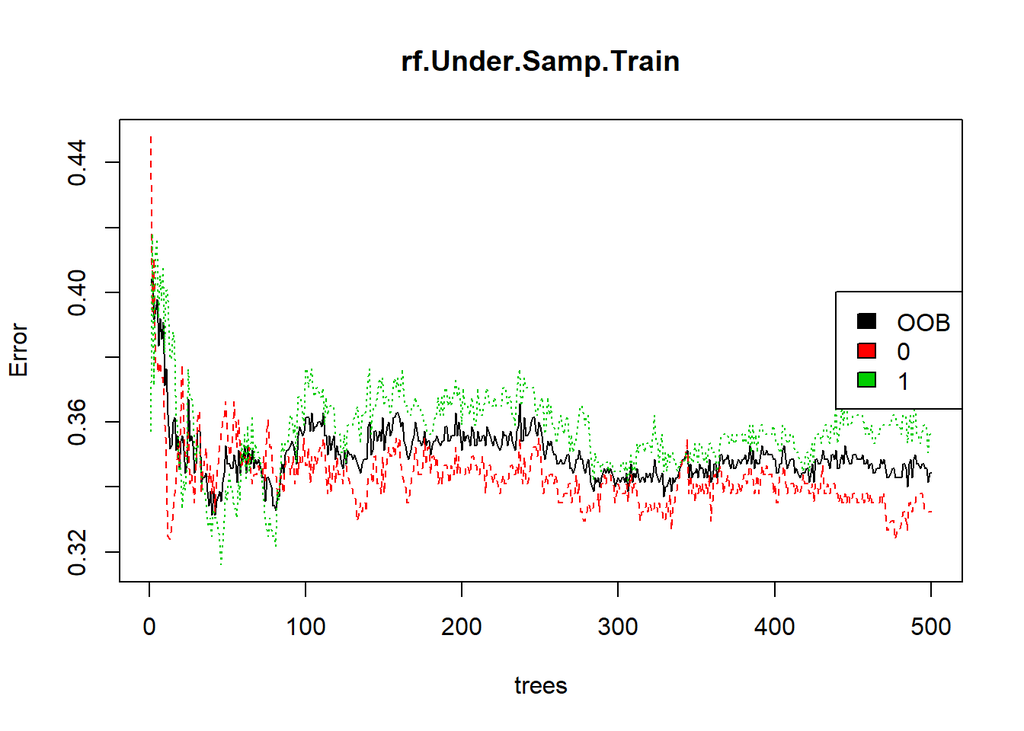

```r
# Plot the model trained in the previous exercise
plot(rf.Under.Samp.Train)

# Add a legend since it doesn't have one by default
legend(x = "right",
       legend = colnames(err),
       fill = 1:ncol(err))
```

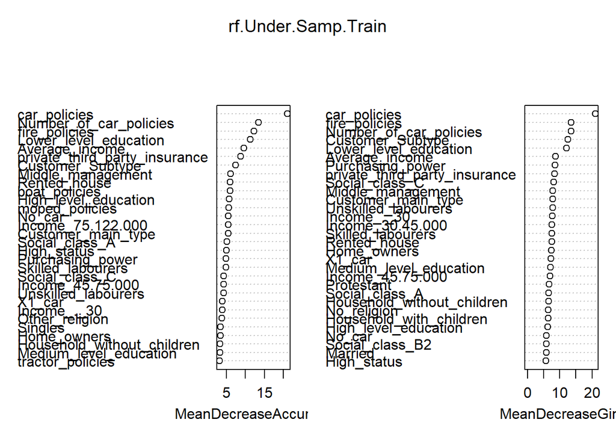

```r
#importan(rf.Under.Samp.Train)
varImpPlot(rf.Under.Samp.Train)
```

```r
# Generate predicted classes using the model object
rf.Under.Samp.Prediction <-  predict(rf.Under.Samp.Train,newdata = Caravan_test,type = "class")

# Calculate the confusion matrix for the test set

cm <- confusionMatrix(as.factor(rf.Under.Samp.Prediction),
                      reference = as.factor(Caravan_test$Number_of_mobile_home_policies) )
print(cm)
```

```
## Confusion Matrix and Statistics
##
##           Reference
## Prediction    0    1
##          0 2455   90
##          1 1307  148
##
##                Accuracy : 0.6508
##                  95% CI : (0.6357, 0.6655)
##     No Information Rate : 0.9405
##     P-Value [Acc > NIR] : 1
##
##                   Kappa : 0.0808
##  Mcnemar's Test P-Value : <2e-16
##
##             Sensitivity : 0.6526
##             Specificity : 0.6218
##          Pos Pred Value : 0.9646
##          Neg Pred Value : 0.1017
##              Prevalence : 0.9405
##          Detection Rate : 0.6138
##    Detection Prevalence : 0.6362
##       Balanced Accuracy : 0.6372
##
##        'Positive' Class : 0
##
```

```r
# Compare test set accuracy to OOB accuracy
paste0("Test Accuracy: ", cm$overall[1])
```

```
## [1] "Test Accuracy: 0.65075"
```

```r
paste0("OOB Accuracy: ", 1 - oob_err)
```

```
## [1] "OOB Accuracy: 0.655714285714286"
```

```r
# Compute the AUC (`actual` must be a binary 1/0 numeric vector)
#library(ROCR)
#install.packages("pROC")
#library(pROC)
#auc(Caravan_test$Number_of_mobile_home_policies,rf.Unb.Prediction)
```

## PERFORMANCE TUNING

###### performance tuning using tuneRF

# Execute the tuning process

```r
set.seed(1)

res <- tuneRF(x = subset(caravan_under_data, select = -Number_of_mobile_home_policies ),
              y = as.factor(caravan_under_data$Number_of_mobile_home_policies),
              ntreeTry = 500)
```

```
## mtry = 7  OOB error = 35%
## Searching left ...
## mtry = 4     OOB error = 34.57%
## 0.0122449 0.05
## Searching right ...
## mtry = 14    OOB error = 32.86%
## 0.06122449 0.05
## mtry = 28    OOB error = 34.14%
## -0.03913043 0.05
```

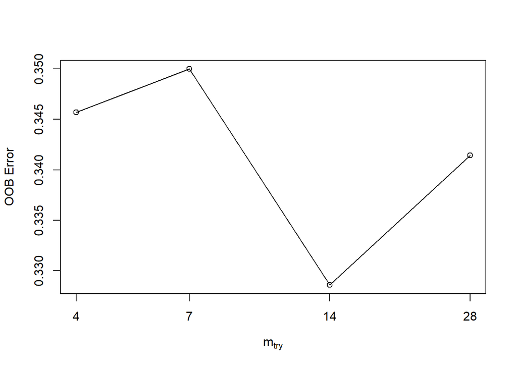

```r
print(res)
```

```
##        mtry  OOBError
## 4.OOB     4 0.3457143
## 7.OOB     7 0.3500000
## 14.OOB   14 0.3285714
## 28.OOB   28 0.3414286
```

```r
# Find the mtry value that minimizes OOB Error
mtry_opt <- res[,"mtry"][which.min(res[,"OOBError"])]
print(mtry_opt)
```

```
## 14.OOB
##     14
```

## Performance tuning using search grid

```r
############ performance tuning using hyper grid
# Establish a list of possible values for mtry, nodesize and sampsize
mtry <- seq(10, ncol(caravan_under_data) * 0.8, 2)
nodesize <- seq(7, 8, 2)
sampsize <- nrow(caravan_under_data) * c(0.7, 0.8)

# Create a data frame containing all combinations
hyper_grid <- expand.grid(mtry = mtry, nodesize = nodesize, sampsize = sampsize)


# Create an empty vector to store OOB error values
oob_err_vector <- c()

nrow(hyper_grid)
```

```
## [1] 36
```

```r
# Write a loop over the rows of hyper_grid to train the grid of models
for (i in 1:nrow(hyper_grid)) {

  print(i)
  print(hyper_grid$mtry[i])
  print( hyper_grid$nodesize[i])
  print(hyper_grid$sampsize[i])

  # Train a Random Forest model
  model <- randomForest(as.factor(Number_of_mobile_home_policies)  ~ . , data = caravan_under_data ,
                        mtry = hyper_grid$mtry[i],
                        nodesize = hyper_grid$nodesize[i],
                        sampsize = hyper_grid$sampsize[i])

  # Store OOB error for the model
  oob_err[i] <- model$err.rate[nrow(model$err.rate), "OOB"]
}
```

```
## [1] 1
## [1] 10
## [1] 7
## [1] 490
## [1] 2
## [1] 12
## [1] 7
## [1] 490
## [1] 3
## [1] 14
## [1] 7
## [1] 490
## [1] 4
## [1] 16
## [1] 7
```

[output cut: 129 more lines]

```r
# Identify optimal set of hyperparmeters based on OOB error
opt_i <- which.min(oob_err)
opt_i
```

```
##
## 7
```

```r
hyper_grid[opt_i,]
```

```
##   mtry nodesize sampsize
## 7   22        7      490
```

```r
print(hyper_grid[opt_i,])
```

```
##   mtry nodesize sampsize
## 7   22        7      490
```